# Assignment 4: Water Quality in Rivers

Theo Cai

## OVERVIEW

This exercise accompanies the lessons in Hydrologic Data Analysis on water quality in rivers.

## Directions

1. Change “Student Name” on line 3 (above) with your name.
2. Work through the steps, **creating code and output** that fulfill each instruction.
3. Be sure to **answer the questions** in this assignment document.
4. When you have completed the assignment, **Knit** the text and code into a single HTML file.
5. After Knitting, submit the completed exercise (HTML file) to the dropbox in Sakai. Add your last name into the file name (e.g., “A04_Chamberlin.html”) prior to submission.

The completed exercise is due on 25 September 2019 at 9:00 am.

## Setup

1. Verify your working directory is set to the R project file,
2. Load the tidyverse, dataRetrieval, cowplot, xts and dygraphs packages.
3. Set your ggplot theme (can be theme_classic or something else)

```r
getwd()
```

```
## [1] "Z:/Hydrologic_Data_Analysis"
```

```r
library(tidyverse)
```

```r
library(dataRetrieval)
library(cowplot)
library(xts)
library(dygraphs)

theme_set(theme_classic())
```

## Hypoxia

This assignment will look at another measure of water quality - oxygen concentration. Though not directly important for human health, oxygen in the water column is very important for aquatic life, and so is considered a measure of water quality. Hypoxia (low oxygen) has many different definitions. For this assignment, we will use 2 mg/L O<sub>2</sub> as our cut-off.

4. Import the oxygen water quality data from New Hope Creek at Blands (using `readNWISqw()`, site code `02097314`, parameter code `00300`). Make a data frame called `O2.dat` that includes only the Date and O<sub>2</sub> concentration values. Give your data frame understandable column names.

```r
#Read in data
dat.raw <- readNWISqw(siteNumbers = "02097314",
                      parameterCd = "00300",
                      startDate = "",
                      endDate = "")
#O2 data frame
O2.dat <- dat.raw %>%
  select(Date = sample_dt,
         Value = result_va) %>%
  rename(Date = 'Date',
         OConcen_mgL = 'Value')
```

5. Create a ggplot of oxygen concentrations over time. Include a horizonal line at 2 mg/l to show the hypoxia cutoff.

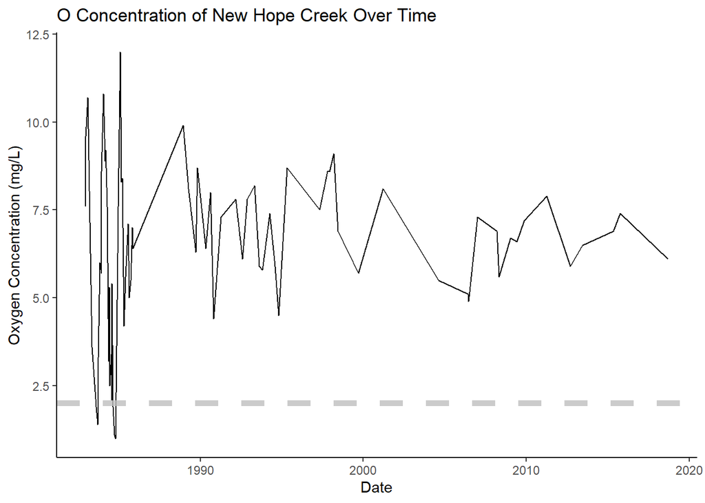

```r
O2.plot <- ggplot(O2.dat, aes(x = Date, y = OConcen_mgL)) +
  geom_line() +
  geom_hline(yintercept = 2, color = "grey", alpha = 0.8, lwd = 2, lty = 2) +
  ggtitle("O Concentration of New Hope Creek Over Time") +
  labs(y = "Oxygen Concentration (mg/L)")

print(O2.plot)
```

6. What do you notice about the frequency of hypoxia overtime?

> I notice that hypoxia occured twice in the early part of the data set, specifically around the mid-1980s, but did not occur a single time afterwards, up until present day.

## Nutrients

7. Often times hypoxia is associated with high nutrient concentrations, because abundant nutrients promote biomass growth which increases respiration and depletes oxygen concentrations in the water (remember how oxygen concentrations were very low in the hypolimnion from the Physical Properties of Lakes week). Create a new data frame, called `nutrients.dat` with total nitrogen (parameter code `00600`) and total phosphorus (parameter code `00665`) data from the USGS. Your data frame should have 3 columns, `Date`, `TotalNitrogen_mgl-N`, and `TotalPhosphorus_mgl-P`.

```r
nutrients.raw <- readNWISqw(siteNumbers = "02097314",
                            parameterCd = c("00600",
                                            "00665"),
                            startDate = "",
                            endDate = "")

nutrients.dat <- nutrients.raw %>%
  select(Date = sample_dt,
         Parameter = parm_cd,
         Value = result_va) %>%
  group_by(Date, Parameter) %>%
  summarize(Value = mean(Value)) %>%
  spread(key = Parameter, value = Value) %>%
  rename(TotalNitrogen_mgl_N = '00600',
         TotalPhosphorus_mgl_P = '00665')
```

8. Create two ggplots stacked with cowplot that show nutrient concentrations over time.

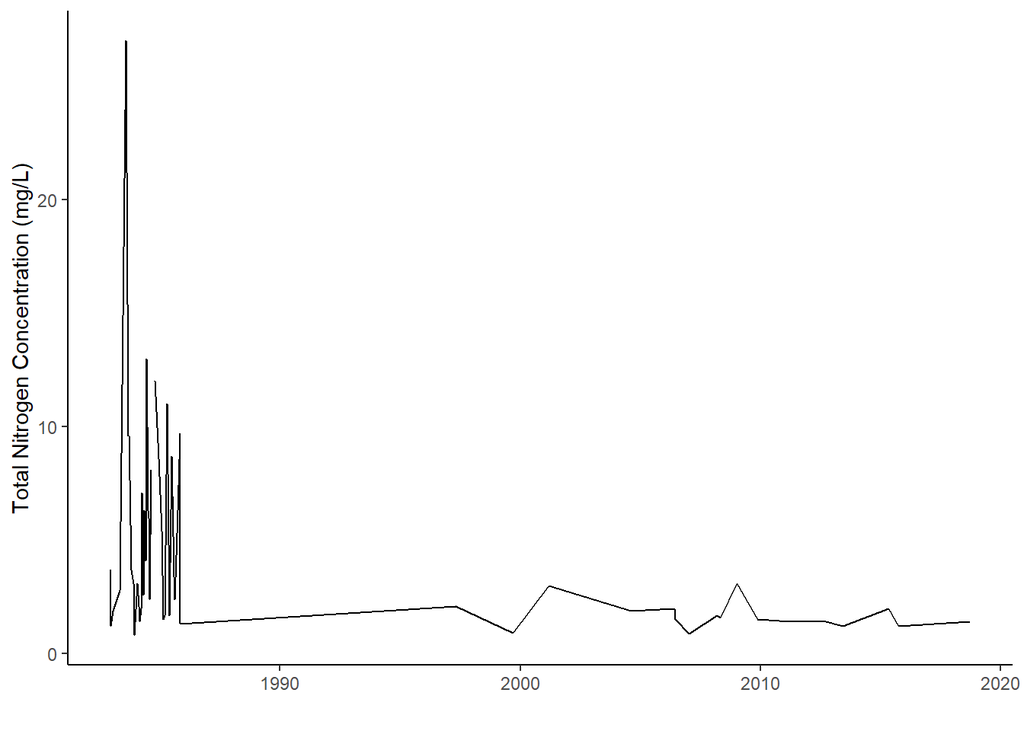

```r
#Nitrogen plot
Nitrogen.plot <- ggplot(nutrients.dat, aes(x = Date)) +
  geom_line(aes(y = TotalNitrogen_mgl_N)) +
  labs(x = "", y = "Total Nitrogen Concentration (mg/L)") +
  theme(legend.position = "top")

print(Nitrogen.plot)
```

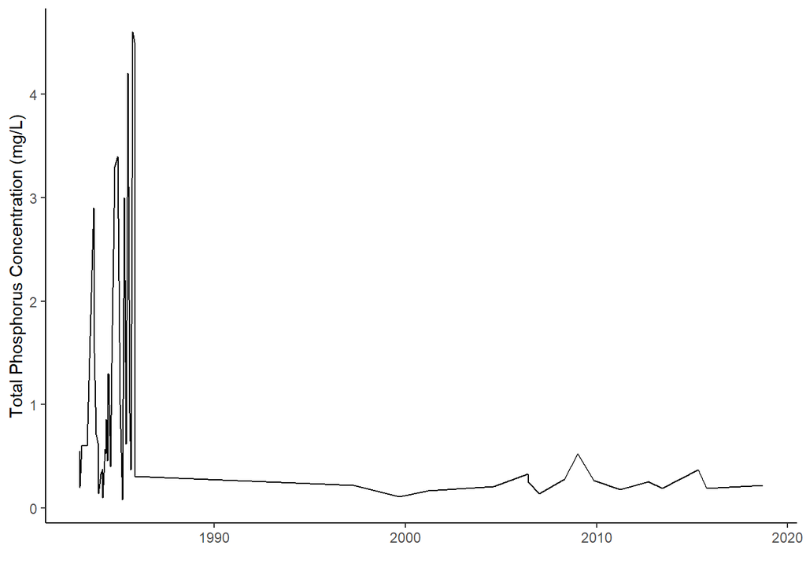

```r
Phosphorus.plot <- ggplot(nutrients.dat, aes(x = Date)) +
  geom_line(aes(y = TotalPhosphorus_mgl_P)) +
  labs(x = "", y = "Total Phosphorus Concentration (mg/L)") +
  theme(legend.position = "top")

print(Phosphorus.plot)
```

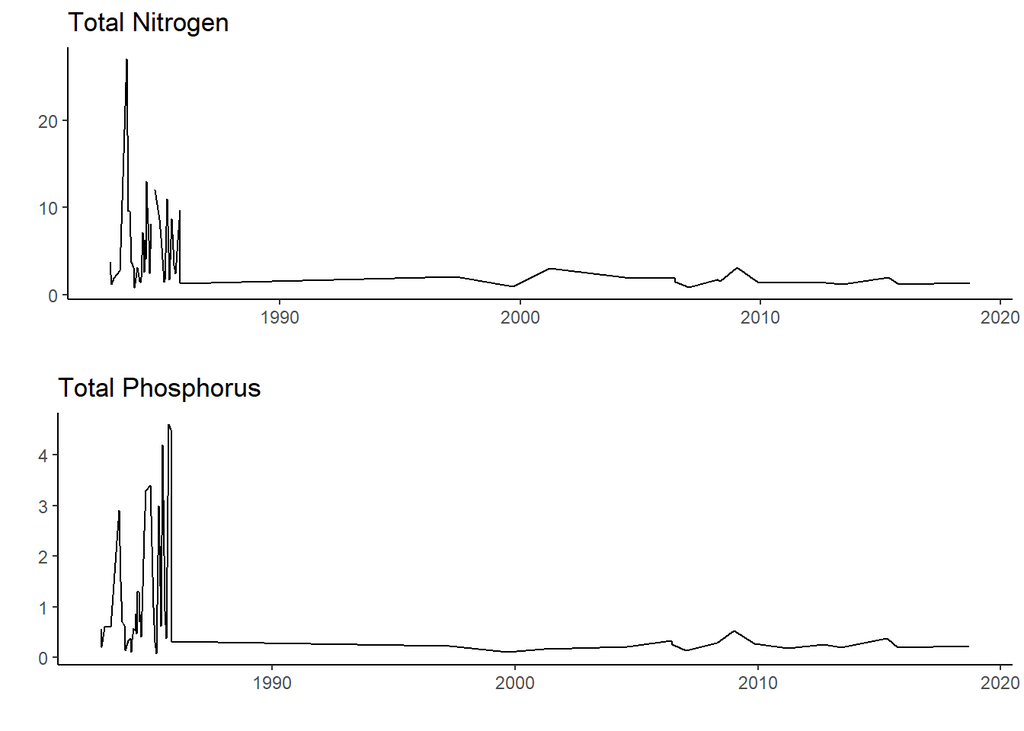

```r
Nutrient.plot <- plot_grid(Nitrogen.plot +
                             labs(title = "Total Nitrogen", y = ""),
                           Phosphorus.plot +
                             labs(title = "Total Phosphorus", y = ""),
                           ncol = 1)

print(Nutrient.plot)
```

9. What do these plots tell you about nutrient concentrations over time? How might this relate to your previous plot of hypoxia events?

> They tell me that, over time, the nutrient concentrations at this location have leveled out despite peaking around the mid-1980s. This might show a correalation between nutrient levels and hypoxia, as the latter events occured around the same time as the nutrient level peaks. This seems to indicate the nutrient level peaks indeed resulted in increase in biomass growth, which consequently lowered the oxygen concentration to dangerous levels.

## Discharge and Temperature

10. Turbulent flow in rivers mixes oxygen into the water column. As discharge decreases, water moves slower, and oxygen diffuses slower into the water from the atmosphere. Download and reformat the daily discharge data for New Hope Creek (function `readNWISdv()`, site `02097314`, parameter `00060`).

```r
discharge.raw <- readNWISdv(siteNumbers = "02097314",
                            parameterCd = "00060",
                            startDate = "",
                            endDate = "")

discharge.dat <- discharge.raw %>%
  select(Date = Date, Discharge_cfs = X_00060_00003)
```

11. Create a dygraph of discharge and oxygen concentrations. You should have discharge on the y axis and oxygen concentration on the y2 axis. Set your y-axes limits so that they don’t change as you zoom in and out. (hint: use `dyAxis(..., valueRange = c(0, 6500))` for discharge & `dyAxis(..., valueRange = c(0, 13))` for oxygen).

```r
OConcentration <- with(O2.dat, xts(x = OConcen_mgL, order.by = Date))
Discharge <- with(discharge.dat, xts(x = Discharge_cfs, order.by = Date))

DyDat <- cbind(OConcentration, Discharge)

dygraph(DyDat) %>%
  dySeries("OConcentration", axis = "y2") %>%
  dyAxis(name = "y", label = "Discharge (cfs)", valueRange = c(0, 6500)) %>%
  dyAxis(name = "y2", label = "Total Oxygen Concentration (mg/L)", valueRange = c(0, 13)) %>%
  dyRangeSelector()
```

[interactive chart not shown]

12. Do hypoxic events happen in the wet or the dry season? How many days after storm events (of at least 100 cfs) do they occur?

> It seems that hypoxic events happen in the dry season. They occur a month or two after storm events of at least 100cfs
13. Temperature also impacts the solubility of oxygen in water. More oxygen can dissolve when temperatures are *lower*. How would you analyze the effects of temperature on dissolved oxygen concentrations? What data would you need? How would you separate the effects of temperature from the effects of flow?

> I would need temperature at the location over a period of time, as well as dissolved oxygen concentrations over a similar period of time. Then I might average both values by month and look at seasonal changes. It would be difficult to separate them completely, as temperature affects precipitation. I would try to exclude extreme discharge events (the times they happened) when looking at the relationship between temperature and O concentrations.
14. What do you think is the biggest driver of hypoxia in New Hope Creek? What data do you use to support your conclusion?

> I think the biggest driver of hypoxia are the nutrient levels (Nitrogen and Phosphorus). I would use the stacked plot of their levels over time and compare that to the O concentration levels over time to support my conclusion.

## Reflection

15. What are 2-3 conclusions or summary points about river water quality you learned through your analysis?

> In conclusion, nutrient levels are by far the most useful predictors of hypoxia. Seasonal variation might account for some O concentration variation, but not on the same scale that Nitrogen and Phosphorus do.
16. What data, visualizations, and/or models supported your conclusions from 15?

> Basically all of the plots I generated support this conclusion: the O concentration one, the stacked plot of nutrient concentrations, and the dygraph of discharge and O concentration.
17. Did hands-on data analysis impact your learning about water quality relative to a theory-based lesson? If so, how?

> Yes! The interactive graph especially helped me go day by day, month by month, and year by year to track possible trends in discharge and O concentration.
18. How did the real-world data compare with your expectations from theory?

> They matched up pretty well. I already knew the impact that Nitrogen and Phosphorus has on oxygen levels, so this lesson just gave me concrete proof.